# UE 11 – Calcul Différentiel, Intégral et Stochastique

# Enquête 2020-2021, Elément Constitutif 1

Compléments à [la synthèse automatique des données](https://boisgera.github.io/CDIS/Enquete/2020/report-2020-2021-EC1.html) fournie par Google forms.

Données brutes : survey-2020-2021-EC1.csv

## Dépendances

```python
# Python Standard Library
import re

# Third-Party Libraries
import matplotlib.pyplot as pp
from matplotlib import cm
pp.rcParams['figure.figsize'] = 16, 5

import numpy as np
import scipy.stats as st
import pandas as pd

from IPython.display import Markdown
```

## Utilitaires

```python
def barplot(df, key, answers, colormap="viridis", alpha=1.0, invert=False):
    data = df[key].dropna() # filter off empty answers
    data = [len(data[data==k])/len(data)*100 for k in answers]
    n = len(answers)
    index = list(range(n))
    pp.xticks(index, answers)
    pp.axis([-0.5, n-0.5, 0, 100])
    pp.grid(True)
    pp.ylabel("Pourcentage")
    pp.yticks(np.linspace(0, 100, 11))
    colormap = cm.get_cmap(colormap)
    xrange = np.linspace(0.0, 1.0, n)
    if invert:
        xrange = 1.0 - xrange
    colors = [colormap(x) for x in xrange]
    _ = pp.bar(index, data, width=1.0, color=colors, alpha=alpha)
    pp.title(key)
```

```python
blacklist = "Jean Auriol Chloé-Agathe Azencott Martin Bauw Pauline Bernard Samy Blusseau Sébastien Boisgérault Delphine Bresch-Pietri Mona Buisson Emilie Chautru Cyril Joly Hubert Ménou Silviu Niculescu Nicolescu Slawomir Pietrasz Thomas Romary Lev-Arcady Sellem Emilia Siviero Dilshad Surroop".split()

pattern = re.compile("|".join(f"({string})" for string in blacklist))

def filter_text(text):
    return pattern.sub(8 * "?", text)
```

```python
def comments(df, number=0, label=None, filter=True):
    key = "Commentaires"
    if number:
        key += f".{number}"
    data = df[key]
    text = "### Commentaires"
    if label:
        text += f" – {label}\n\n"
    for item in df[key]:
        if isinstance(item, str) and item:
            text += f" - {item}\n\n"
    if filter:
        text = filter_text(text)
    return Markdown(text)
```

```python
def hist_diff(df, label=None, color="black", kde=True):
    data = df["Difficulté"]
    m, s = np.nanmean(data), np.nanstd(data)
    n = len(data)
    try:
        label += f" ({n} élèves)"
    except:
        pass
    pp.hist(data, bins=np.linspace(0.0, 3.0001, 4*3 + 1), density=True, color=color, alpha=0.15,label=label)
    pp.legend()

    if len(data)>= 5:
        data.plot.kde(lw=2, color=color)
    bottom, top = pp.gca().get_ylim()
    pp.plot([m, m], [0.0, top], "-", color=color)
    if len(data) >= 5:
        pp.plot([m-s, m-s], [0.0, top], "--", color=color, alpha=0.5)
        pp.plot([m+s, m+s], [0.0, top], "--", color=color, alpha=0.5)
    pp.axis([0, 3, bottom, top])

    pp.xticks([0.0, 0.5, 1.0, 1.5, 2.0, 2.5, 3.0], ["trop faible", "", "plutôt faible", "(moyenne)", "plutôt forte", "", "trop forte"])
    pp.yticks([])
    pp.title("Difficulté")

    pp.ylabel("Densité")
```

```python
def hist_interest(df, label=None, color="black"):
    data = df["Intérêt"]
    m, s = np.nanmean(data), np.nanstd(data)
    n = len(data)
    try:
        label += f" ({n} élèves)"
    except:
        pass
    pp.hist(data, bins=np.linspace(0.0, 3.0001, 4*3 + 1), density=True, color=color, alpha=0.15,label=label)
    pp.legend()

    if len(data) >= 5:
        data.plot.kde(lw=2, color=color)
    bottom, top = pp.gca().get_ylim()
    pp.plot([m, m], [0.0, top], "-", color=color)
    if len(data) >= 5:
        pp.plot([m-s, m-s], [0.0, top], "--", color=color, alpha=0.5)
        pp.plot([m+s, m+s], [0.0, top], "--", color=color, alpha=0.5)
    pp.axis([0, 3, bottom, top])

    pp.xticks([0.0, 1.0, 1.5, 2.0, 3.0], ["Faible", "Plutôt faible", "", "Plutôt fort", "Fort"])
    pp.yticks([])
    pp.title("Intérêt/Utilité")

    pp.ylabel("Densité")
```

## Données

```python
df = pd.read_csv("survey-2020-2021-EC1.csv")
```

### Calculs préalables

Nous calculons la difficulté globale avec la difficulté de chaque thème, pondérée par le nombre de sessions qu'il occupe.

```python
diff = {"Trop facile": 0 , "Plutôt facile": 1, "Plutôt difficile": 2, "Trop difficile": 3}
df["TO"] = df["Le thème X de l'enseignement vous a paru [Topologie]"].map(diff)
df["CD"] = df["Le thème X de l'enseignement vous a paru [Calcul différentiel]"].map(diff)
df["CI"] = df["Le thème X de l'enseignement vous a paru [Calcul intégral]"].map(diff)
df["PR"] = df["Le thème X de l'enseignement vous a paru [Probabilités]"].map(diff)
df["Difficulté"] = (df["TO"] + 2* df["CD"] + 3 * df["CI"] + 2 * df["PR"]) / 8
```

```python
interest = {"Pas du tout": 0 , "Plutôt non": 1, "Plutôt oui": 2, "Tout à fait": 3}
df["TO.U"] = df["Le thème X de l'enseignement vous a semblé utile / pertinent / intéressant [Topologie]"].map(interest)
df["CD.U"] = df["Le thème X de l'enseignement vous a semblé utile / pertinent / intéressant [Calcul différentiel]"].map(interest)
df["CI.U"] = df["Le thème X de l'enseignement vous a semblé utile / pertinent / intéressant [Calcul intégral]"].map(interest)
df["PR.U"] = df["Le thème X de l'enseignement vous a semblé utile / pertinent / intéressant [Probabilités]"].map(interest)
df["Intérêt"] = (df["TO.U"] + 2* df["CD.U"] + 3 * df["CI.U"] + 2 * df["PR.U"]) / 8
```

```python
df["Note Examen / 20"] = pd.to_numeric(df["Note Examen / 20"], downcast="float", errors="coerce")
```

### Catégories

Filières d'origine :

```python
MP = df[df["Filière d'origine"]=="MP/MP* : classe préparatoire Mathématiques-Physique"]
PSI = df[df["Filière d'origine"]=="PSI/PSI* : classe préparatoire Physique-Sciences de l'Ingénieur"]
PC = df[df["Filière d'origine"]=="PC/PC* : classe préparatoire Physique-Chimie"]
PT = df[df["Filière d'origine"]=="PT/PT* : classe préparatoire Physique-Technologie"]
TSI = df[df["Filière d'origine"]=="TSI : classe préparatoire Technologie et Sciences Industrielles"]
ATS = df[df["Filière d'origine"]=="ATS : classe préparatoire Adaptation Technicien Supérieur"]
AST_Fr = df[df["Filière d'origine"]=="AST Fr. : admis sur titres (France)"]
AST_Etr = df[df["Filière d'origine"]=="AST Etr. : admis sur titres (Etranger)"]
```

```python
GS = df.loc[[5, 10, 19, 30, 39, 67, 91, 8]] # déterminé manuellement (les réponses sont parfois erronées).
```

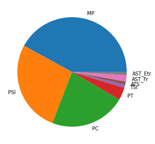

```python
labels = ["MP", "PSI", "PC", "PT", "TSI", "ATS", "AST_Fr", "AST_Etr"]
_ = pp.pie([len(eval(label)) for label in labels], labels=labels)
```

## Satisfaction

L'enseignement est jugé globalement un peu mieux que "plutôt satisfaisant", avec aucune opinion "insatisfaite" exprimée et moins de 5 % d'opinions "plutôt insatisfaites" exprimées. Cette satisfaction est également assez peu sensible par rapport à la filière d'origine ; ce sont les MP qui préfèrent légèrement plus l'enseignement et les filières ATS, AST, TSI qui sont légèrement moins satisfaites (en moyenne tout de même "plutôt satisfaites" avec 2.0 / 3.0 ; attention toutefois aux analyses les concernant car elle ne sont basées que sur 5 réponses).

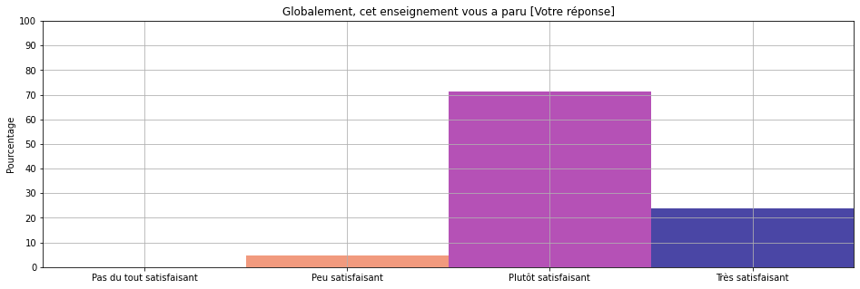

```python
barplot(
    df,
    "Globalement, cet enseignement vous a paru [Votre réponse]",
    ["Pas du tout satisfaisant", "Peu satisfaisant", "Plutôt satisfaisant", "Très satisfaisant"],
    colormap="plasma", alpha=0.75, invert=True
    )
```

```python
mapping = {"Pas satisfaisant": 0, "Peu satisfaisant": 1, "Plutôt satisfaisant": 2, "Très satisfaisant": 3}
df["Satisfaction"] = df["Globalement, cet enseignement vous a paru [Votre réponse]"].map(mapping)
dfs = df.dropna(subset=["Satisfaction"])
print("Satisfaction moyenne:", np.round(np.nanmean(dfs["Satisfaction"]), 2), "/ 3.0")
dfs.groupby("Filière d'origine")["Satisfaction"].agg(["mean", "count"]).sort_values("count").style.format({"mean" : "{0:,.1f} / 3.0"}).bar(color='#FFA07A', align='zero', subset=["mean"]).bar(color='lightgreen', align='zero', subset=["count"]).set_caption("Satisfaction, par filière")
```

```
Satisfaction moyenne: 2.19 / 3.0
```

Satisfaction, par filière

| Filière d'origine | mean | count |
| --- | --- | --- |
| AST Etr. : admis sur titres (Etranger) | 2.0 / 3.0 | 1 |
| ATS : classe préparatoire Adaptation Technicien Supérieur | 2.0 / 3.0 | 1 |
| TSI : classe préparatoire Technologie et Sciences Industrielles | 2.0 / 3.0 | 1 |
| AST Fr. : admis sur titres (France) | 2.0 / 3.0 | 2 |
| PT/PT* : classe préparatoire Physique-Technologie | 2.2 / 3.0 | 4 |
| PC/PC* : classe préparatoire Physique-Chimie | 2.1 / 3.0 | 23 |
| PSI/PSI* : classe préparatoire Physique-Sciences de l'Ingénieur | 2.1 / 3.0 | 29 |
| MP/MP* : classe préparatoire Mathématiques-Physique | 2.3 / 3.0 | 44 |

```python
groupe_1 = df.loc[[5, 10, 19, 30, 39, 67, 91, 8]]
```

## Difficulté perçue

L'enseignement est perçu en moyenne comme (un peu plus dur que) "moyennement difficile". Les variations d'une filière d'origine à l'autre sont assez faibles pour les PC, PSI et MP (les trois filières les plus importantes en volume), mais assez importante au sein de chaque filière.

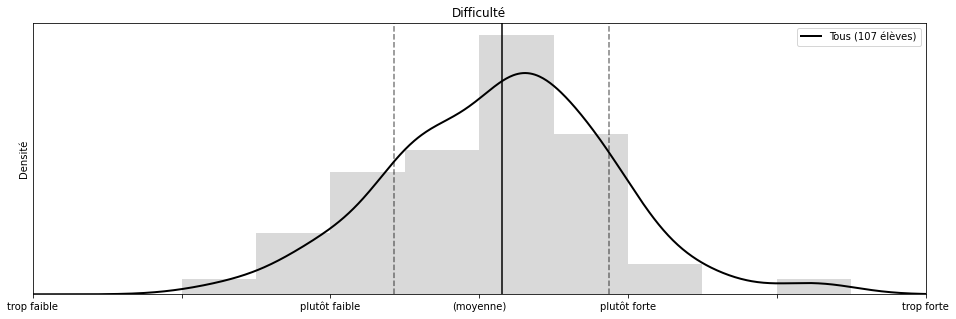

```python
hist_diff(df, label="Tous")
```

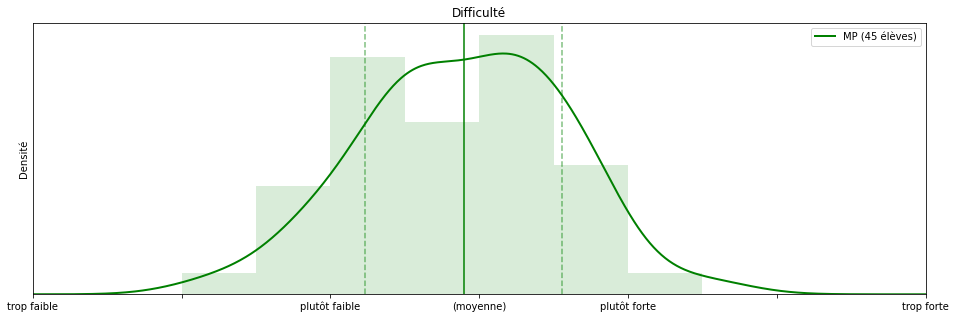

```python
hist_diff(MP, label="MP", color="green")
```

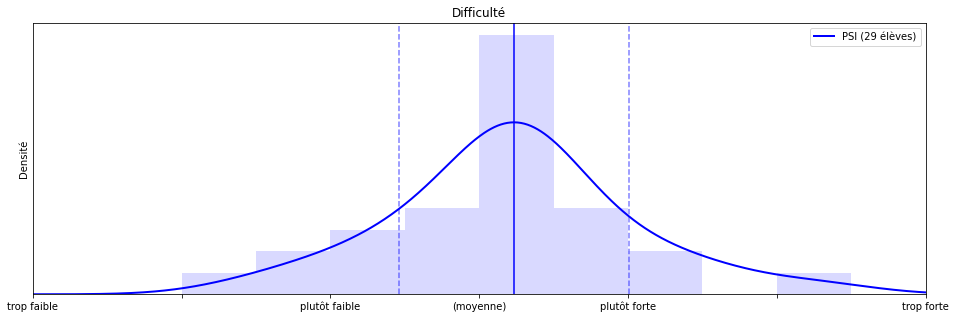

```python
hist_diff(PSI, label="PSI", color="blue")
```

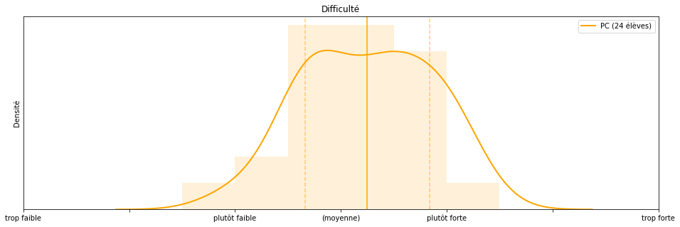

```python
hist_diff(PC, label="PC", color="orange")
```

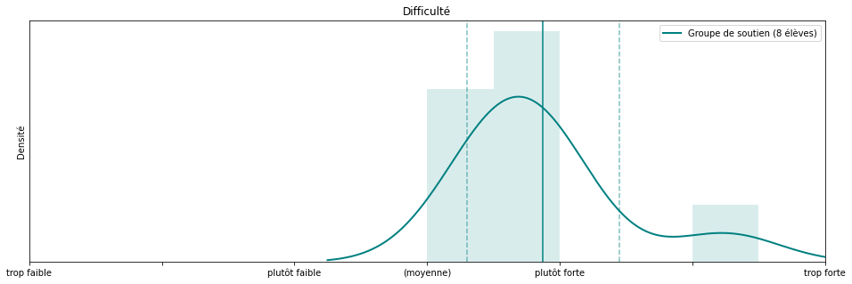

```python
hist_diff(GS, label="Groupe de soutien", color="teal")
```

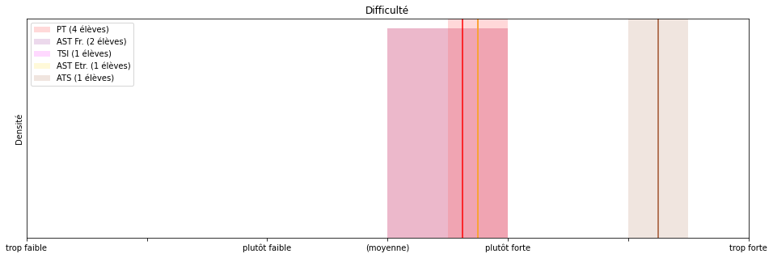

```python
hist_diff(PT, label="PT", color="red")
hist_diff(AST_Fr, label="AST Fr.", color="purple")
hist_diff(TSI, label="TSI", color="magenta")
hist_diff(AST_Etr, label="AST Etr.", color="gold")
hist_diff(ATS, label="ATS", color="sienna")
```

### Difficulté perçue et note à l'examen

La note à l'examen diminue en moyenne avec la difficulté (perçue) de l'enseignement. Toutefois, cette corrélation est plus forte pour les PC que les PSI et a fortiori pour les MP ; pour les MP la difficulté perçue de l'enseignement n'est plus un facteur explicatif significatif de la note à l'examen.

```
corrélation Note / Difficulté : -0.32
```

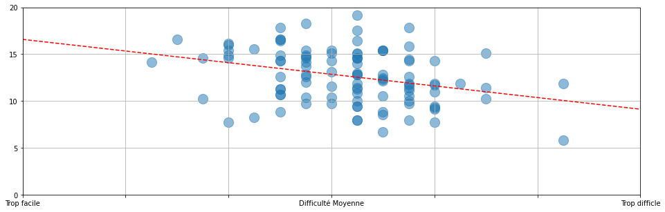

```python
pp.scatter(df["Difficulté"], df["Note Examen / 20"], alpha=0.5, s=200)
pp.yticks([0.0, 5.0, 10.0, 15.0, 20.0])
pp.xticks([0.0, 0.5, 1.0, 1.5, 2.0, 2.5, 3.0], ["Trop facile", "", "", "Difficulté Moyenne", "", "", "Trop difficle"])
pp.grid(True)
pp.axis([0.0, 3.0, 0.0, 20.0])

dfv = df[df["Note Examen / 20"].notnull() & df["Difficulté"].notnull()]
X, Y = dfv["Difficulté"], dfv["Note Examen / 20"]
print(f"corrélation Note / Difficulté : {X.corr(Y):.2g}")

Xs, Ys = dfv["Difficulté"].to_numpy().reshape((-1, 1)), dfv["Note Examen / 20"].to_numpy().reshape((-1, 1))
from sklearn.linear_model import LinearRegression
lr = LinearRegression()
lr.fit(Xs, Ys)
m, M = lr.predict([[0.0], [3.0]])
_ = pp.plot([0, 3.0], [m, M], "r--")
```

```
MP: corrélation Note / Difficulté : -0.046
PSI: corrélation Note / Difficulté : -0.28
PC: corrélation Note / Difficulté : -0.45
```

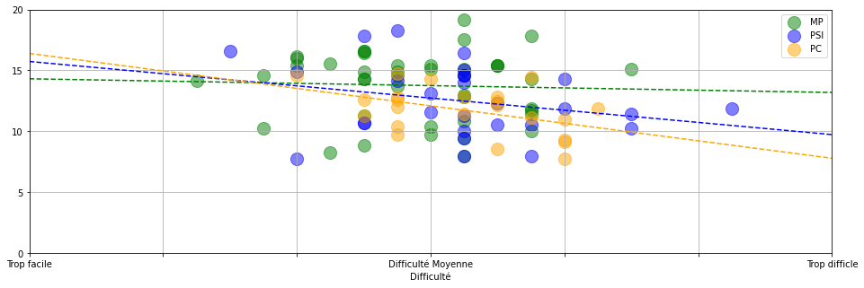

```python
pp.figure()
pp.xticks([0.0, 0.5, 1.0, 1.5, 2.0, 2.5, 3.0], ["Trop facile", "", "", "Difficulté Moyenne", "", "", "Trop difficle"])
pp.yticks([0.0, 5.0, 10.0, 15.0, 20.0])

def s(df, label, color):
    dfv = df[df["Note Examen / 20"].notnull() & df["Difficulté"].notnull()]
    X, Y = dfv["Difficulté"], dfv["Note Examen / 20"]
    print(f"{label}: corrélation Note / Difficulté : {X.corr(Y):.2g}")

    Xs = df["Difficulté"].to_numpy().reshape((-1, 1))
    Ys = df["Note Examen / 20"].to_numpy().reshape((-1, 1))

    # Sklearn doesn't like nan
    is_ = [i for i in range(len(Xs)) if not np.isnan(Xs[i]) and not np.isnan(Ys[i])]
    lr = LinearRegression()
    lr.fit(Xs[is_], Ys[is_])
    pp.scatter(Xs, Ys, color=color, alpha=0.5, s=200, label=label)
    [m, M] = lr.predict([[0.0], [3.0]])
    pp.plot([0.0, 3.0], [m, M], "--", color=color)
    pp.xlabel("Difficulté")

s(MP, "MP", "green")
s(PSI, "PSI", "blue")
s(PC, "PC", "orange")

pp.grid(True)
pp.axis([0.0, 3.0, 0.0, 20.0])
_ = pp.legend()
```

## Intéret & Utilité de l'enseignement

L'intérêt/utilité perçu de l'enseignement est bonne (supérieure à "plutôt forte"). La variabilité selon la filière d'origine est relativement faible. Il ne semble pas y avoir de lien évident entre la difficulté perçue de l'enseignement et son intérêt/utilité.

```
Intérêt/utilité de l'enseignement : 2.26 / 3.0
```

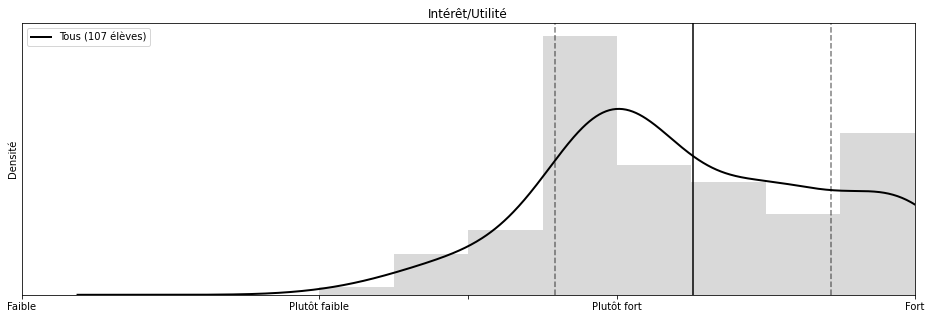

```python
print("Intérêt/utilité de l'enseignement :", round(np.nanmean(df["Intérêt"]), 2), "/ 3.0")
hist_interest(df, label="Tous")
```

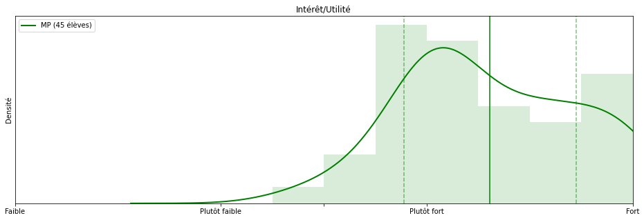

```python
hist_interest(MP, label="MP", color="green")
```

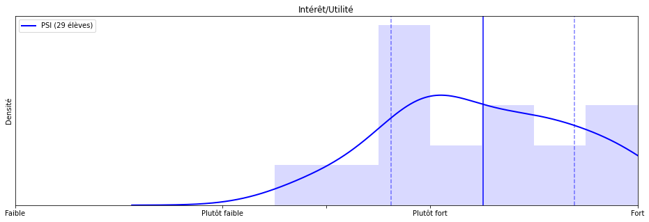

```python
hist_interest(PSI, label="PSI", color="blue")
```

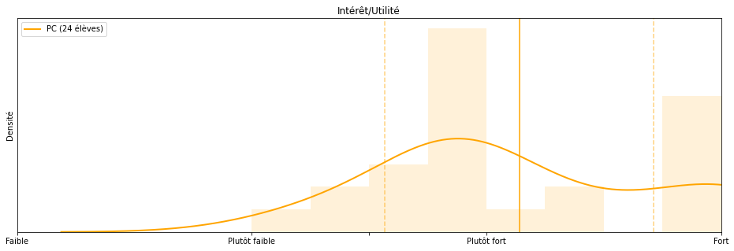

```python
hist_interest(PC, label="PC", color="orange")
```

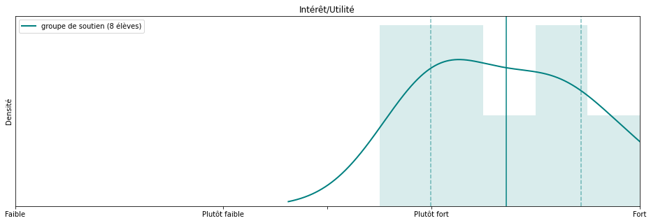

```python
hist_interest(GS, label="groupe de soutien", color="teal")
```

[figure not shown]

```python
hist_interest(PT, label="TSI", color="red")
hist_interest(AST_Fr, label="AST Fr.", color="purple")
hist_interest(TSI, label="TSI", color="magenta")
hist_interest(AST_Etr, label="AST Etr.", color="gold")
hist_interest(ATS, label="ATS", color="sienna")
```

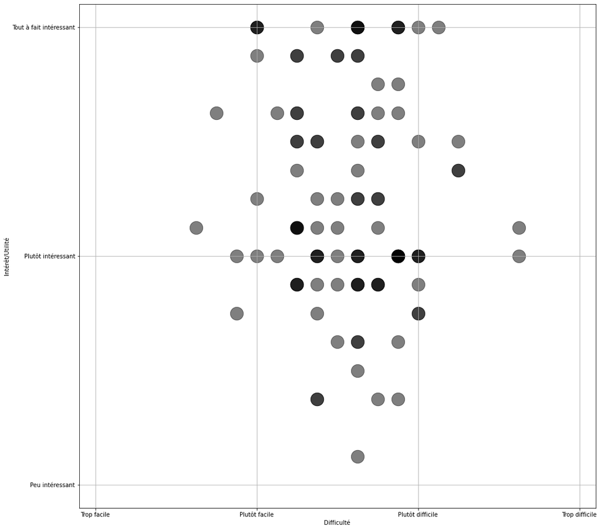

```python
df_ = df
color="black"

pp.scatter(df_["Difficulté"].to_numpy(), df_["Intérêt"].to_numpy(), alpha=0.5, s=500, c=color)
pp.axis([-0.1, 3.1, 0.9, 3.1])
pp.xlabel("Difficulté")
pp.ylabel("Intérêt/Utilité")
pp.xticks([0, 1, 2, 3],["Trop facile", "Plutôt facile", "Plutôt difficile", "Trop difficile"])
pp.yticks([1, 2, 3],["Peu intéressant", "Plutôt intéressant", "Tout à fait intéressant"])
pp.gcf().set_size_inches(16,16)
pp.grid(True)
```

## Groupe de soutien

Des étudiants se sont positionnés incorrectement comme appartenant au groupe de soutien (groupe 1). Les données corrigées manuellement, ci-dessous, montrent une satisfaction légèrement inférieure à la moyenne concernant l'enseignement (attendu compte tenu des filière d'origine des participants), mais le sentiment assez net d'avoir bénéficié de cette formule.

```python
groupe_1 = df.loc[[5, 10, 19, 30, 39, 67, 91, 8]] # déterminé manuellement (les réponses sont parfois erronées).
groupe_1["Satisfaction"]
```

```
5     3.0
10    2.0
19    2.0
30    2.0
39    2.0
67    2.0
91    2.0
8     2.0
Name: Satisfaction, dtype: float64
```

```python
print("Satisfaction :",  np.mean(groupe_1["Satisfaction"]), "/ 3.0")
```

```
Satisfaction : 2.125 / 3.0
```

```python
groupe_1['Vous êtes globalement satisfait des travaux dirigés [Votre réponse]']
```

```
5     Oui, tout à fait
10    Oui, tout à fait
19    Oui, tout à fait
30    Oui, tout à fait
39          Plutôt oui
67          Plutôt non
91          Plutôt oui
8     Oui, tout à fait
Name: Vous êtes globalement satisfait des travaux dirigés [Votre réponse], dtype: object
```

```python
groupe_1['Vous pensez avoir bénéficié du groupe de soutien (si vous en avez fait partie).']
```

```
5     Oui, tout à fait
10          Plutôt oui
19    Oui, tout à fait
30    Oui, tout à fait
39    Oui, tout à fait
67          Plutôt oui
91          Plutôt oui
8                  NaN
Name: Vous pensez avoir bénéficié du groupe de soutien (si vous en avez fait partie)., dtype: object
```

## Tutorats

#### Participation et satisfaction

**Tutorats classiques.** Approximativement la moitié des étudiants a participé régulièrement ou occasionnellement (au moins une fois sur trois) aux tutorats classiques. Parmi les étudiants assidus, on trouve

1. des étudiants des filières PT, AST, ATS et TSI pour un quart (plus du double de leur poids dans la promotion),
2. des étudiants issus de MP, approximativement dans la même proportion que dans la promotion (!),
3. des étudiants issus de PSI et PC, mais dans des proportions moindres que dans la promotion.

Les étudiants issus des filières PT, AST, ATS et TSI ou le poids des Mathématiques est en général plus faible, sont a priori en recherche d'un soutien/tutorat actif en Mathématiques. Les motivations des MPs sont probablement très différenciées avec sans doute la recherche d'un lieu d'étude et/ou l'envie d'aller plus loin. On retrouvera beaucoup plus de PSI et PC en participants occasionnels. On remarquera enfin que tous les étudiants issus de PT, AST, ATS et TSI semblent participer régulièrement ou occasionnellement aux tutorats classiques (les étudiants participant peu ou pas aux tutorats classiques sont tous issus des 3 filières MP, PSI, ou PC).

La satisfaction quant aux tutorats classique est bonne, avec ~ 85% de plutôt ou tout à fait satisfait. Mais cette proportion passe à 100% avec les PT, AST, ATS et TSI (dont une majorité de "tout à fait satisfait") ; ils sont donc actuellement les principaux bénéficiaires de la formule des tutorats classiques. La proportion de satisfaits retombe à moins de 80% pour les MPs qui ont participé aux tutorats classiques.

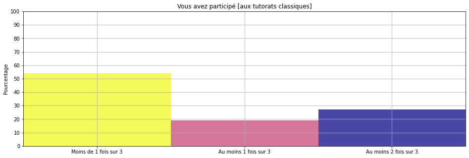

```python
barplot(
    df,
    "Vous avez participé [aux tutorats classiques]",
    ["Moins de 1 fois sur 3", "Au moins 1 fois sur 3", "Au moins 2 fois sur 3"],
    colormap="plasma", alpha=0.75, invert=True
    )
```

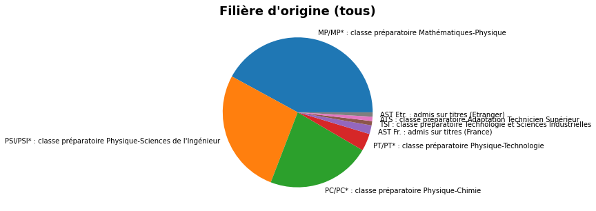

```python
origin = list(df["Filière d'origine"])
labels = list(set(origin)) # get all possible labels, exactly once
# sort them (largest category first)
labels = sorted(labels, key=lambda label: -len(df[df["Filière d'origine"]==label]))
_ = pp.pie([len([item for item in origin if item == label]) for label in labels], labels=labels)
_ = pp.gca().set_title("Filière d'origine (tous)", fontweight="bold", fontsize=18)
```

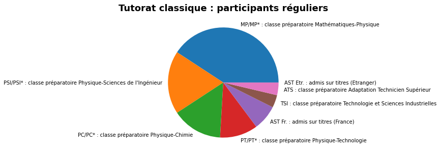

```python
index = df["Vous avez participé [aux tutorats classiques]"] == "Au moins 2 fois sur 3"
dfi = df[index]
origin = list(dfi["Filière d'origine"])
_ = pp.pie([len([item for item in origin if item == label]) for label in labels], labels=labels)
_ = pp.gca().set_title("Tutorat classique : participants réguliers", fontweight="bold", fontsize=18)
```

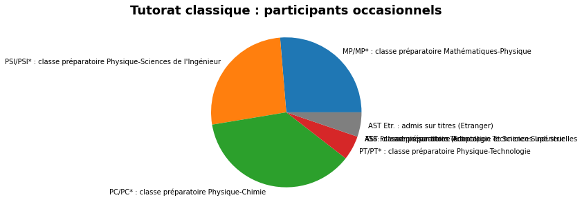

```python
index = df["Vous avez participé [aux tutorats classiques]"] == "Au moins 1 fois sur 3"
dfi = df[index]
origin = list(dfi["Filière d'origine"])
_ = pp.pie([len([item for item in origin if item == label]) for label in labels], labels=labels)
_ = pp.gca().set_title("Tutorat classique : participants occasionnels", fontweight="bold", fontsize=18)
```

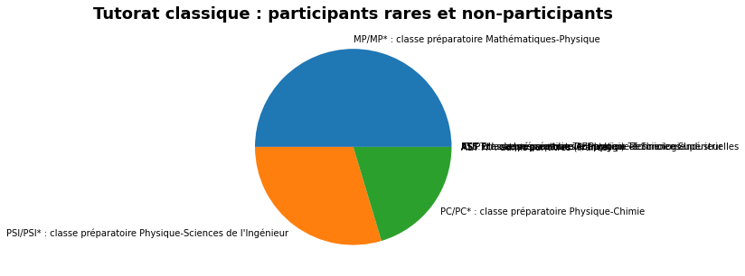

```python
index = df["Vous avez participé [aux tutorats classiques]"] == "Moins de 1 fois sur 3"
dfi = df[index]
origin = list(dfi["Filière d'origine"])
_ = pp.pie([len([item for item in origin if item == label]) for label in labels], labels=labels)
_ = pp.gca().set_title("Tutorat classique : participants rares et non-participants", fontweight="bold", fontsize=18)
```

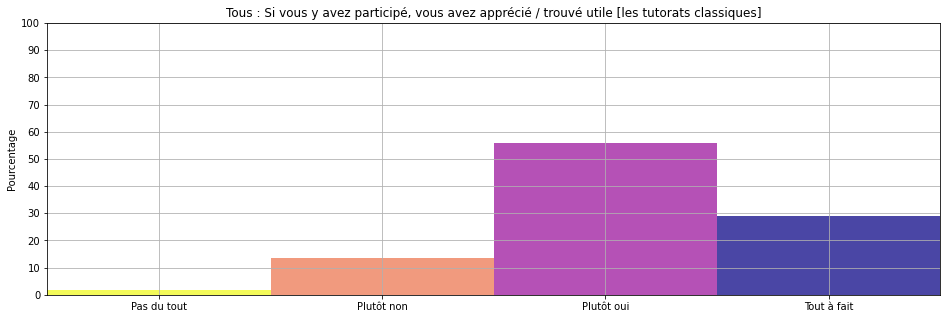

```python
barplot(
    df,
    "Si vous y avez participé, vous avez apprécié / trouvé utile [les tutorats classiques]",
    ["Pas du tout", "Plutôt non", "Plutôt oui", "Tout à fait"],
    colormap="plasma", alpha=0.75, invert=True
)
_ = pp.gca().set_title("Tous : " + pp.gca().get_title())
```

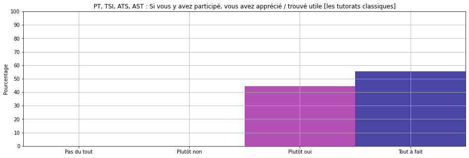

```python
l = ["PT/PT* : classe préparatoire Physique-Technologie",
"TSI : classe préparatoire Technologie et Sciences Industrielles",
"ATS : classe préparatoire Adaptation Technicien Supérieur",
"AST Fr. : admis sur titres (France)",
"AST Etr. : admis sur titres (Etranger)"]
index = df["Filière d'origine"].isin(l)
dfi = df[index]
barplot(
    dfi,
    "Si vous y avez participé, vous avez apprécié / trouvé utile [les tutorats classiques]",
    ["Pas du tout", "Plutôt non", "Plutôt oui", "Tout à fait"],
    colormap="plasma", alpha=0.75, invert=True
)
_ = pp.gca().set_title("PT, TSI, ATS, AST : " + pp.gca().get_title())
```

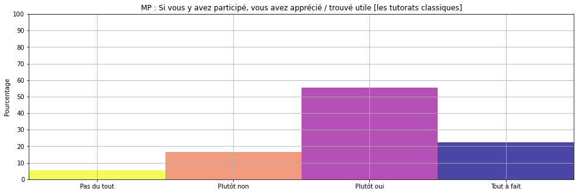

```python
l = ["MP/MP* : classe préparatoire Mathématiques-Physique"]
#PSI = df[df["Filière d'origine"]=="PSI/PSI* : classe préparatoire Physique-Sciences de l'Ingénieur"]
#PC = df[df["Filière d'origine"]=="PC/PC* : classe préparatoire Physique-Chimie"]
index = df["Filière d'origine"].isin(l)
dfi = df[index]
barplot(
    dfi,
    "Si vous y avez participé, vous avez apprécié / trouvé utile [les tutorats classiques]",
    ["Pas du tout", "Plutôt non", "Plutôt oui", "Tout à fait"],
    colormap="plasma", alpha=0.75, invert=True
)
_ = pp.gca().set_title("MP : " + pp.gca().get_title())
```

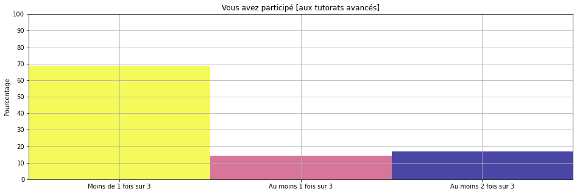

```python
barplot(
    df,
    "Vous avez participé [aux tutorats avancés]",
    ["Moins de 1 fois sur 3", "Au moins 1 fois sur 3", "Au moins 2 fois sur 3"],
    colormap="plasma", alpha=0.75, invert=True
    )
```

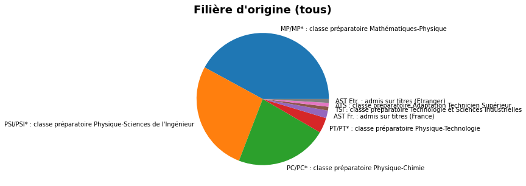

```python
origin = list(df["Filière d'origine"])
labels = list(set(origin)) # get all possible labels, exactly once
# sort them (largest category first)
labels = sorted(labels, key=lambda label: -len(df[df["Filière d'origine"]==label]))
_ = pp.pie([len([item for item in origin if item == label]) for label in labels], labels=labels)
_ = pp.gca().set_title("Filière d'origine (tous)", fontweight="bold", fontsize=18)
```

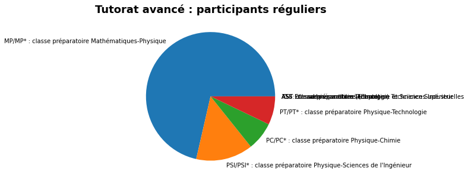

```python
index = df["Vous avez participé [aux tutorats avancés]"] == "Au moins 2 fois sur 3"
dfi = df[index]
origin = list(dfi["Filière d'origine"])
_ = pp.pie([len([item for item in origin if item == label]) for label in labels], labels=labels)
_ = pp.gca().set_title("Tutorat avancé : participants réguliers", fontweight="bold", fontsize=18)
```

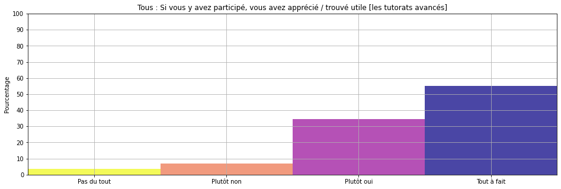

```python
barplot(
    df,
    "Si vous y avez participé, vous avez apprécié / trouvé utile [les tutorats avancés]",
    ["Pas du tout", "Plutôt non", "Plutôt oui", "Tout à fait"],
    colormap="plasma", alpha=0.75, invert=True
)
_ = pp.gca().set_title("Tous : " + pp.gca().get_title())
```

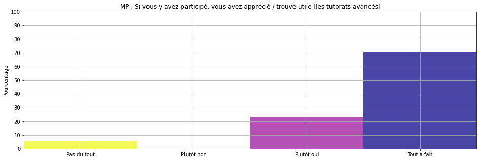

```python
l = ["MP/MP* : classe préparatoire Mathématiques-Physique"]
index = df["Filière d'origine"].isin(l)
dfi = df[index]
barplot(
    dfi,
    "Si vous y avez participé, vous avez apprécié / trouvé utile [les tutorats avancés]",
    ["Pas du tout", "Plutôt non", "Plutôt oui", "Tout à fait"],
    colormap="plasma", alpha=0.75, invert=True
)
_ = pp.gca().set_title("MP : " + pp.gca().get_title())
```

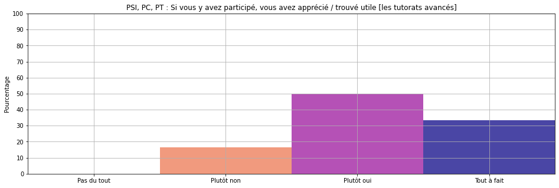

```python
l = ["PSI/PSI* : classe préparatoire Physique-Sciences de l'Ingénieur",
"PC/PC* : classe préparatoire Physique-Chimie",
"PT/PT* : classe préparatoire Physique-Technologie"]
index = df["Filière d'origine"].isin(l)
dfi = df[index]
barplot(
    dfi,
    "Si vous y avez participé, vous avez apprécié / trouvé utile [les tutorats avancés]",
    ["Pas du tout", "Plutôt non", "Plutôt oui", "Tout à fait"],
    colormap="plasma", alpha=0.75, invert=True
)
_ = pp.gca().set_title("PSI, PC, PT : " + pp.gca().get_title())
```